# Some ways to calculate and present summary statistics

John Little

2021-02-05

## Load library packages

In addition to using the `gapminder` dataset, I will also use the base-R dataset, `faithful` (C:/Users/jrl/Documents/R/R-4.0.3/library/datasets/help/faithful) and the dplyr dataset `starwars` (C:/Users/jrl/Documents/R/R-4.0.3/library/dplyr/help/starwars). Below I have commented out the `install.packages()` function. If you do not have these functions, you may need to run those commands.

```r
library(tidyverse)
# install.packages("gapminder")
library(gapminder)
# install.packages("skimr")
library(skimr)
```

## Summary Statiscs

The base-R function, `summary()` is a very convenient way of showing min, max, mean, median, and interquartile range

```r
summary(faithful)
```

```
   eruptions        waiting
 Min.   :1.600   Min.   :43.0
 1st Qu.:2.163   1st Qu.:58.0
 Median :4.000   Median :76.0
 Mean   :3.488   Mean   :70.9
 3rd Qu.:4.454   3rd Qu.:82.0
 Max.   :5.100   Max.   :96.0
```

The `skimr::skim()` function is helpful and includes “spark graphs” at the end of each numeric variable. The spark graphs show distribution – and can be turned off with `skim_without_charts()`

```r
skim(faithful)
```

```
-- Data Summary ------------------------
                           Values
Name                       faithful
Number of rows             272
Number of columns          2
_______________________
Column type frequency:
  numeric                  2
________________________
Group variables            None

-- Variable type: numeric -----------------------------------------------------------------------------------------------
# A tibble: 2 x 11
  skim_variable n_missing complete_rate  mean    sd    p0   p25   p50   p75  p100 hist
* <chr>             <int>         <dbl> <dbl> <dbl> <dbl> <dbl> <dbl> <dbl> <dbl> <chr>
1 eruptions             0             1  3.49  1.14   1.6  2.16     4  4.45   5.1 ▇▂▂▇▇
2 waiting               0             1 70.9  13.6   43   58       76 82     96   ▃▃▂▇▂
```

```r
faithful %>%
  skim_without_charts()
```

```
-- Data Summary ------------------------
                           Values
Name                       Piped data
Number of rows             272
Number of columns          2
_______________________
Column type frequency:
  numeric                  2
________________________
Group variables            None

-- Variable type: numeric -----------------------------------------------------------------------------------------------
# A tibble: 2 x 10
  skim_variable n_missing complete_rate  mean    sd    p0   p25   p50   p75  p100
* <chr>             <int>         <dbl> <dbl> <dbl> <dbl> <dbl> <dbl> <dbl> <dbl>
1 eruptions             0             1  3.49  1.14   1.6  2.16     4  4.45   5.1
2 waiting               0             1 70.9  13.6   43   58       76 82     96
```

## Visualization

Another great way to display summary statistics on numeric variables is to display boxplots that display common statistics: the median, interquartile range, etc.

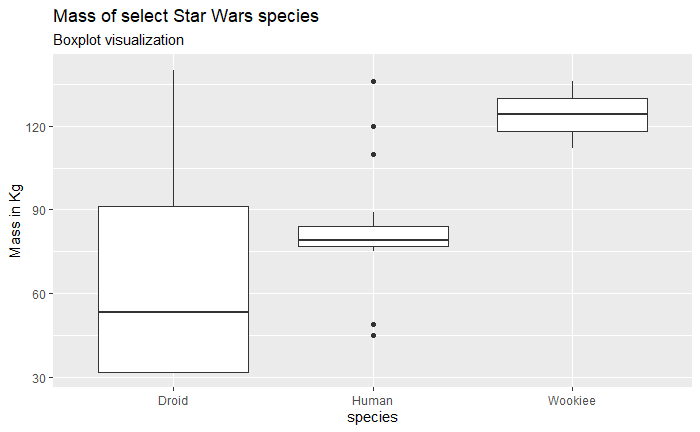

```r
starwars %>%
  filter(mass < 500) %>%
  filter(species == "Human" |
           species == "Droid" |
           species == "Wookiee") %>%
  ggplot(aes(species, mass)) +
  geom_boxplot() +
  labs(title = "Mass of select Star Wars species",
       subtitle = "Boxplot visualization",
       y = "Mass in Kg")
```

## Tidyverse approach

The original developer of [qwraps library](https://github.com/dewittpe/qwraps) seems to have abandon his approach in favor of tidyverse methods. I tend to agree.

```r
faithful %>%
  # group_by(waiting) %>%
  summarise(mean   = mean(eruptions, na.rm = TRUE),
            median = median(eruptions, na.rm = TRUE),
            min    = min(eruptions, na.rm = TRUE),
            max    = max(eruptions, na.rm = TRUE),
            sd     = sd(eruptions, na.rm = TRUE))
```

| mean | median | min | max | sd |
| --- | --- | --- | --- | --- |
| 3.487783 | 4 | 1.6 | 5.1 | 1.141371 |

```r
# gapminder %>%
#   group_by(continent, year) %>%
#   skim()
```

## Print

Skimr can have some funny output options but there is plenty of documentation on the options. Many of those idiosyncrasies are also easily handled with Tidyverse approaches to printing dataframes (e.g. the `kintr::kable()` function, `kableExtra`, and/or [gt](https://gt.rstudio.com/).)

```r
foo <- faithful %>%
  skim()



# foo %>%
#   knit_print()
```